# A3: SPL Library Checkouts

### Introduction

I chose to analyze the data set containing all the items checked out in 2022-2023. I will be specifically analyzing Sally Rooney’s books: *Normal People*, *Conversations With Friends*, and *Beautiful World, Where Are You.* Sally Rooney is an Irish author and screenwriter whose books have gained immense popularity since Hulu’s adaptation of *Normal People.* I have read two of her books so I wanted to analyze her as an author to see her checkout popularity in 2022 by determining which months Rooney had the best and worst number of check outs and what publisher resulted in the most check outs. I also wanted to compare the three books to each other to see which is the the most popular and what the average number of checkouts were for the top book compared to the others. I also wanted to determine what her most common checkout material type is because I have purchased both a physical paper copy and digital eBook of her books. I’m interested in analyzing Sally Rooney because I have really enjoyed her books so far and would like to know if her third book is worth reading. If it is more popular than the other two and gaining in popularity, it would compel me to read it!

### The Dataset

The data set was collected by The Seattle Public Library and published by Seattle Open Data. It is also displayed on Legrady’s art installation at the library for customers to view in real time. The data was collected to help predict which books are least likely to be checked out in order for the library to utilize premium shelf space for books in higher demand as it changes due to seasonal, social, political, and cultural reasons. The data is also publicly known to generate economic opportunity for individuals and companies, and to improve public understanding of city operations and other information concerning their communities. The data is collected from designed statistical and algorithmic software that maps the flow of data received from the library’s Information Technology center. They also received previous data from the Legrady artwork data archives, and digital purchases from digital libraries: OverDrive, hoopla, Freegal, and RBDigital.

The data set originally consists of 12 columns: book’s usage class (physical or digital), how the book was checked out, the medium of the book (audiobook, ebook, physical copy), the year and month the book was checked out in, the number of checkouts for the book that month, the title of the book, the book’s IBSN number, the author, the subject of the book, the publisher, and the publication year. The SPL 2022-2023 checkout data set contains 2,757014 observations but the data set only containing Sally Rooney’s books has 109 observations. The data does not appear to violate customer privacy as it does not collect their data, only information about the books. But if the library was collecting customer data, this would be an ethical question to consider. Otherwise, I do not think there are any ethical questions for this data set because the data is collected straight from the source/transaction and sent directly to the library’s Information Technology Center leaving no room to question how it is collected, stored, and exchanged. And, each book is pre categorized into the subject, title, author, material type, etc. so the information system only has to read these labels, not compute or analyze the book itself to create results.

One possible problem when working with this data set is that there are missing/blank data values. For instance some of the books have missing authors, IBSN numbers, or subject descriptions. This is mostly seen in the older checkout dates because of the historical archive, but can cause some problems when trying to analyze the data. Having missing data values essentially makes that book unusable for analysis which then results in skewed results.

### First Trends Over Time Chart: Number of Books Checkouts Over the Year

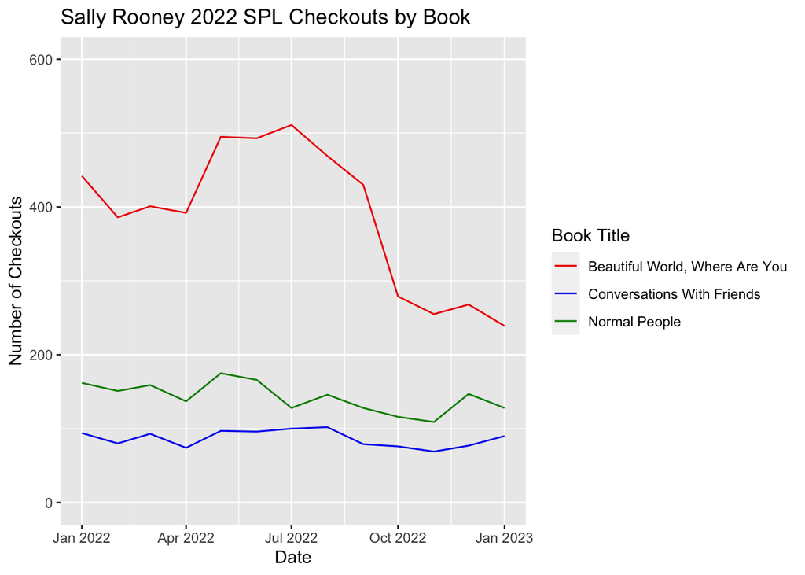

This chart depicts the number of checkouts at the Seattle Public Library for each of Sally Rooney’s books over the course of 2022. I chose to visualize this because I wanted to determine which of her books was the most popular, and how its checkout numbers compared to the other books. I also wanted to see if her books had a steady checkout rate over the year, or if there were certain times the checkout numbers were higher or lower. After creating the chart, I was able to determine that Rooney’s book *Beautiful World, Where Are You* was her most popular book checked out in the Seattle Public Library in 2022. I noticed this particular book had an increase in checkouts from May to August, around summertime. The other two books were significantly lower than *Beautiful World, Where Are You* with *Normal People* averaging at what looks to be around 150 checkouts per month and *Conversations With Friends* averaging at approximately 75 checkouts per moth. They both seem to have a small spike in their checkouts in May but otherwise were fairly consistent throughout the year. I believe these trends may have to do with the release dates of the books as *Beautiful World, Where Are You* is Rooney’s newest book and *Conversations With Friends* is her oldest. However I was surprised that *Normal People* did not have more checkouts as I thought this would be her most popular book due to the Hulu TV adaptation of it.

### Second Trends Over Time Chart: Material Type Total Checkouts Over the Year

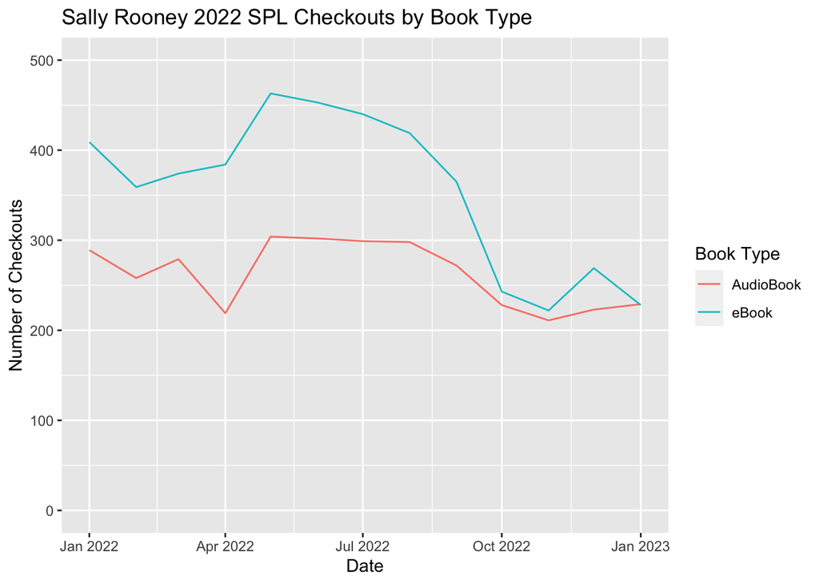

This chart visualizes the different types of mediums Sally Rooney’s books were checked out as at the Seattle Public Library in 2022. I was interested in these trend lines because when I read two of Rooney’s books, I purchased one paper copy and one digital eBook copy. So, I was curious to see how other people in Seattle were reading her works. After analyzing the chart, it is clear to see that more eBooks than AudioBooks have been checked out for Rooney this past year. It is interesting to note that the gap between AudioBooks and eBooks is fairly consistent in the beginning the year with them both having an increase in May. But around September they both decrease, with eBook checkouts decrease at a higher rate than AudioBook checkouts, resulting in the two mediums being almost equal. Another pattern I recognized is that when the checkouts for Rooney’s books all spike in Chart 1 during May and decrease in September/October, the number of AudioBooks and eBooks also spike and fall in this chart. One thing that surprised me about this graph is that there are only two types of mediums this book was checked out as in 2022 at the Seattle Public Library. I was shocked that there were no paper copies checked out the entire year and wondered if this was maybe due to a lack of physical copies at the library, which, if true, could be an important factor to consider when analyzing the original data set: the physical book stock of the library.

### Your Choice: Total Checkouts for Each Publisher

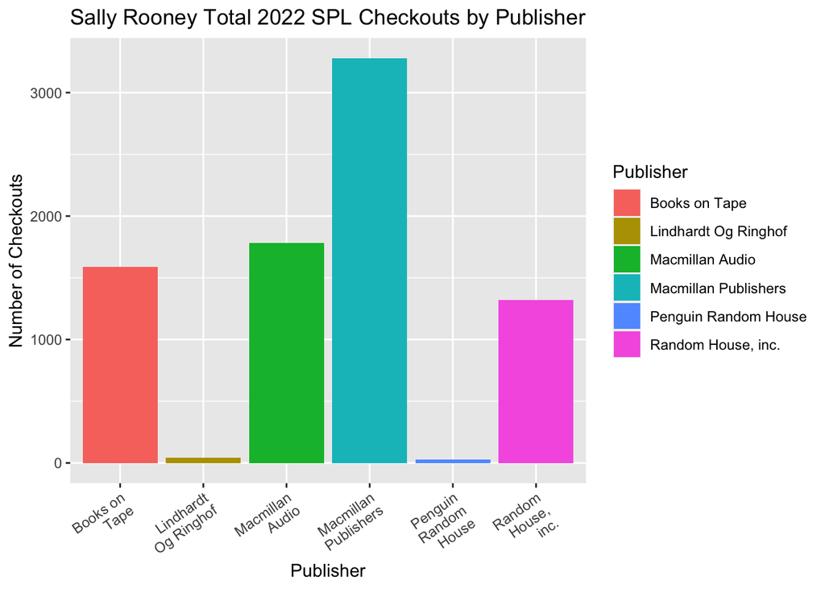